# RNA-seq: Raw FASTQ to Read Counts Tutorial

## 4.0 Converting BAM files to FASTQ

```bash
# install samtools: http://www.sthda.com/english/wiki/install-samtools-on-unix-system

# for one file
samtools fastq bamfile.bam > name_of_fastq_file.fastq

# for multiple files
for file in *.bam; do samtools fastq $file > ${file//.bam/.fastq}; done
```

## 5.0 Bulk renaming of files using `Windows Powershell`.

The sequencing files from the GSC come with the suffix *_1_75bp_4_lanes.merge_chastity_passed*. To remove, do the following in [Windows Powershell](https://www.windowscentral.com/how-rename-multiple-files-bulk-windows-10#rename-files-using-powershell):

```bash
#change to working directory
cd /d E:

ls | Rename-Item -NewName {$_.name -replace "_1_75bp_4_lanes.merge_chastity_passed", ""}
```

To remove the last few characters, use:

```bash
Get-ChildItem | rename-item -newname { $_.name.substring(0,$_.name.length-6) }
# where -6 is 6 letters to be removed from the end
```

Similarly, you can remove any of the prexifes supplied while trimming the files.

## 6.0 BAM to Expression Read Count Files

Once you have your BAM files, extracting the counts for your reads (i.e. how many times was a particular transcript was sequenced) is straightforward, and you can do it in R itself using the {Rsubread} package

Check all of the available arguments and options available for the featureCounts function by running `?featureCounts` in your console

```r
library(Rsubread)

aligned <- featureCounts(here::here("data", "your_BAM_file.bam"), annot.inbuilt = "hg19", isPairedEnd = TRUE)
```

[figure not shown]

Output you’ll get by running featurecounts

```r
expression_counts <- aligned$counts

head(counts)
```

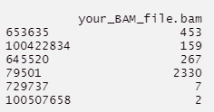

```r
knitr::include_graphics("Z:/Nikita/Misc_R_Scripts/featurecounts_head.png", error = FALSE)
```